# Melting Point Data

Harper Schwab

9/22/2020

## Introduction

```r
library(tidyverse)
library(dplyr)
#
#Load mouse data
mp <- read.csv("dirtyMPdata.csv", header = TRUE)
```

## Cleaning data

To start I looked at the data demographics.

```r
names(mp)
```

```
##  [1] "ï..structure"  "mp"            "rings"         "heavy.atoms"
##  [5] "single.bonds"  "triple.bonds"  "reactive"      "molar.mass"
##  [9] "refractivity"  "formal.charge" "logP"          "tpsa"
## [13] "dipole.moment" "energy"        "density"       "volume"
## [17] "PCA1"          "PCA2"
```

```r
dim(mp)
```

```
## [1] 4450   18
```

```r
str(mp)
```

```
## 'data.frame':    4450 obs. of  18 variables:
##  $ ï..structure : chr  "O=C1Cc2ccccc21" "Clc1ccc(cc1)C1c2c(OC(N)=C1C#N)[nH][nH0]c2C(F)(F)F" "O=C(OC)C(=Cc1ccccc1)Cc1ccccc1" "FC(F)(F)c1[nH0]cc2ccccc2c1" ...
##  $ mp           : num  14 20.5 27.5 30.5 31 31.5 32 32.5 33 34 ...
##  $ rings        : int  6 11 12 10 6 6 6 5 12 12 ...
##  $ heavy.atoms  : int  9 23 19 14 12 14 12 10 16 14 ...
##  $ single.bonds : int  9 20 22 10 16 19 14 12 21 16 ...
##  $ triple.bonds : int  0 1 0 0 0 0 0 0 0 0 ...
##  $ reactive     : int  0 0 0 0 1 0 0 0 0 0 ...
##  $ molar.mass   : num  118 341 252 197 162 ...
##  $ refractivity : num  3.56 7.73 7.8 4.73 4.65 ...
##  $ formal.charge: int  0 0 0 0 0 0 0 0 0 0 ...
##  $ logP         : num  1.43 3.64 3.49 3.57 1.94 ...
##  $ tpsa         : num  17.1 87.7 26.3 12.9 26.3 ...
##  $ dipole.moment: num  2.72 6.32 1.91 5.2 1.76 ...
##  $ energy       : num  -57.8 -189.1 -123.5 -119.7 -83.5 ...
##  $ density      : num  0.959 1.296 0.946 1.195 0.978 ...
##  $ volume       : num  123 263 267 165 166 ...
##  $ PCA1         : num  15.55 1.92 2.98 11.03 10.97 ...
##  $ PCA2         : num  1.622 0.502 2.723 1.826 -0.905 ...
```

```r
sapply(mp, class)
```

```
##  ï..structure            mp         rings   heavy.atoms  single.bonds
##   "character"     "numeric"     "integer"     "integer"     "integer"
##  triple.bonds      reactive    molar.mass  refractivity formal.charge
##     "integer"     "integer"     "numeric"     "numeric"     "integer"
##          logP          tpsa dipole.moment        energy       density
##     "numeric"     "numeric"     "numeric"     "numeric"     "numeric"
##        volume          PCA1          PCA2
##     "numeric"     "numeric"     "numeric"
```

```r
head(mp)
```

```
##                                        ï..structure   mp rings heavy.atoms
## 1                                    O=C1Cc2ccccc21 14.0     6           9
## 2 Clc1ccc(cc1)C1c2c(OC(N)=C1C#N)[nH][nH0]c2C(F)(F)F 20.5    11          23
## 3                     O=C(OC)C(=Cc1ccccc1)Cc1ccccc1 27.5    12          19
## 4                        FC(F)(F)c1[nH0]cc2ccccc2c1 30.5    10          14
## 5                               O=C(OC1Cc2ccccc21)C 31.0     6          12
## 6                            O=C(OC)C1=Cc2ccccc2C1C 31.5     6          14
##   single.bonds triple.bonds reactive molar.mass refractivity formal.charge
## 1            9            0        0    118.135     3.557232             0
## 2           20            1        0    340.692     7.729887             0
## 3           22            0        0    252.313     7.799344             0
## 4           10            0        0    197.159     4.729193             0
## 5           16            0        1    162.188     4.651153             0
## 6           19            0        0    188.226     5.533352             0
##       logP  tpsa dipole.moment     energy   density   volume    PCA1    PCA2
## 1 1.425370 17.07      2.722717  -57.76601 0.9589853 123.1875 15.5507  1.6219
## 2 3.637884 87.72      6.320718 -189.06262 1.2962539 262.8281  1.9216  0.5024
## 3 3.485670 26.30      1.911006 -123.45357 0.9463216 266.6250  2.9803  2.7226
## 4 3.565100 12.89      5.203625 -119.71445 1.1952425 164.9531 11.0316  1.8263
## 5 1.942370 26.30      1.759848  -83.47468 0.9782332 165.7969 10.9710 -0.9051
## 6 2.360100 26.30      2.046720  -95.11963 0.9741601 193.2188  8.9700  0.3246
```

```r
tail(mp)
```

```
##                                                 ï..structure  mp rings
## 4445                        N=1CCNC=1Cc1c(C)cc(cc1C)C(C)(C)C 131     6
## 4446            O=C(OC)C1C(O)CCC2CN3CCc4c5ccccc5[nH]c4C3CC21 234     9
## 4447              O=C1NC(=O)C(C)=CN1C1OC(CO)C(N=[N+]=[N-])C1 106     0
## 4448                             s1c2ccccc2cc1C(N(O)C(=O)N)C 157     9
## 4449 [S+2]([O-])([O-])(C)c1ccc(cc1)c1[nH0]c2[nH0](C=CC=C2)c1 242    11
## 4450                      Clc1ccc2Sc3ccccc3C=C(OCCN(C)C)c2c1  90    12
##      heavy.atoms single.bonds triple.bonds reactive molar.mass refractivity
## 4445          18           37            0        0    245.390     7.652000
## 4446          26           46            0        1    355.458     9.993037
## 4447          19           28            0        1    267.245     6.299167
## 4448          16           18            0        1    236.295     6.457717
## 4449          19           20            0        0    272.328     7.474073
## 4450          22           30            0        0    332.875     9.547561
##      formal.charge    logP   tpsa dipole.moment    energy   density   volume
## 4445             1 1.22571  26.00     13.028417 -112.7691 0.8720617 281.3906
## 4446             1 1.32547  66.76      8.226915 -177.9712 1.0188236 348.8906
## 4447             0 0.22820 103.59      4.728840 -146.1079 1.1644663 229.5000
## 4448             0 2.82770  66.56      1.821058 -112.0673 1.0833784 218.1094
## 4449             0 2.45110  51.96      8.410813 -127.4689 1.0959562 248.4844
## 4450             1 3.26210  13.67     23.597216 -146.3722 1.0327710 322.3125
##         PCA1    PCA2
## 4445  2.2338  1.6217
## 4446 -3.7905 -1.1574
## 4447  2.7954 -7.6893
## 4448  5.4399 -3.3301
## 4449  3.0028 -0.5994
## 4450 -0.2923  4.3546
```

```r
glimpse(mp)
```

```
## Rows: 4,450
## Columns: 18
## $ ï..structure  <chr> "O=C1Cc2ccccc21", "Clc1ccc(cc1)C1c2c(OC(N)=C1C#N)[nH]...
## $ mp            <dbl> 14.0, 20.5, 27.5, 30.5, 31.0, 31.5, 32.0, 32.5, 33.0,...
## $ rings         <int> 6, 11, 12, 10, 6, 6, 6, 5, 12, 12, 6, 14, 11, 6, 6, 6...
## $ heavy.atoms   <int> 9, 23, 19, 14, 12, 14, 12, 10, 16, 14, 11, 22, 18, 12...
## $ single.bonds  <int> 9, 20, 22, 10, 16, 19, 14, 12, 21, 16, 13, 26, 23, 17...
## $ triple.bonds  <int> 0, 1, 0, 0, 0, 0, 0, 0, 0, 0, 0, 0, 0, 0, 0, 0, 0, 0,...
## $ reactive      <int> 0, 0, 0, 0, 1, 0, 0, 0, 0, 0, 0, 1, 0, 0, 0, 0, 0, 0,...
## $ molar.mass    <dbl> 118.135, 340.692, 252.313, 197.159, 162.188, 188.226,...
## $ refractivity  <dbl> 3.557232, 7.729887, 7.799344, 4.729193, 4.651153, 5.5...
## $ formal.charge <int> 0, 0, 0, 0, 0, 0, 0, 0, 0, 0, 0, 0, 0, 0, 0, 0, 0, 0,...
## $ logP          <dbl> 1.425370, 3.637884, 3.485670, 3.565100, 1.942370, 2.3...
## $ tpsa          <dbl> 17.070000, 87.720001, 26.299999, 12.890000, 26.299999...
## $ dipole.moment <dbl> 2.7227166, 6.3207178, 1.9110060, 5.2036252, 1.7598478...
## $ energy        <dbl> -57.76601, -189.06262, -123.45357, -119.71445, -83.47...
## $ density       <dbl> 0.9589853, 1.2962539, 0.9463216, 1.1952425, 0.9782332...
## $ volume        <dbl> 123.1875, 262.8281, 266.6250, 164.9531, 165.7969, 193...
## $ PCA1          <dbl> 15.5507, 1.9216, 2.9803, 11.0316, 10.9710, 8.9700, 10...
## $ PCA2          <dbl> 1.6219, 0.5024, 2.7226, 1.8263, -0.9051, 0.3246, 0.75...
```

```r
summary(mp)
```

```
##  ï..structure             mp            rings         heavy.atoms
##  Length:4450        Min.   : 14.0   Min.   : 0.000   Min.   : 6.00
##  Class :character   1st Qu.:117.5   1st Qu.: 6.000   1st Qu.:17.00
##  Mode  :character   Median :161.5   Median :11.000   Median :22.00
##                     Mean   :165.3   Mean   : 9.956   Mean   :22.24
##                     3rd Qu.:209.4   3rd Qu.:12.000   3rd Qu.:26.00
##                     Max.   :392.5   Max.   :36.000   Max.   :59.00
##
##   single.bonds     triple.bonds       reactive        molar.mass
##  Min.   :  4.00   Min.   :0.0000   Min.   :0.0000   Min.   : 84.08
##  1st Qu.: 19.00   1st Qu.:0.0000   1st Qu.:0.0000   1st Qu.:243.27
##  Median : 24.00   Median :0.0000   Median :0.0000   Median :308.33
##  Mean   : 28.24   Mean   :0.1058   Mean   :0.2209   Mean   :317.41
##  3rd Qu.: 33.00   3rd Qu.:0.0000   3rd Qu.:0.0000   3rd Qu.:375.38
##  Max.   :119.00   Max.   :4.0000   Max.   :1.0000   Max.   :815.62
##
##   refractivity    formal.charge           logP             tpsa
##  Min.   : 1.992   Min.   :-3.00000   Min.   :-6.023   Min.   :  0.00
##  1st Qu.: 6.609   1st Qu.: 0.00000   1st Qu.: 2.106   1st Qu.: 38.33
##  Median : 8.310   Median : 0.00000   Median : 3.221   Median : 61.07
##  Mean   : 8.514   Mean   : 0.01236   Mean   : 3.337   Mean   : 67.50
##  3rd Qu.:10.179   3rd Qu.: 0.00000   3rd Qu.: 4.529   3rd Qu.: 88.06
##  Max.   :19.354   Max.   : 2.00000   Max.   :12.780   Max.   :413.24
##
##  dipole.moment         energy           density           volume
##  Min.   :  0.000   Min.   :-489.00   Min.   :0.7945   Min.   : 78.89
##  1st Qu.:  2.375   1st Qu.:-186.18   1st Qu.:0.9812   1st Qu.:230.77
##  Median :  3.811   Median :-150.42   Median :1.0540   Median :285.19
##  Mean   :  5.210   Mean   :-157.51   Mean   :1.0804   Mean   :294.47
##  3rd Qu.:  5.633   3rd Qu.:-118.36   3rd Qu.:1.1432   3rd Qu.:349.31
##  Max.   :248.303   Max.   : -44.35   Max.   :1.8956   Max.   :728.58
##                    NA's   :13
##       PCA1               PCA2
##  Min.   :-33.7975   Min.   :-19.9754
##  1st Qu.: -4.1177   1st Qu.: -2.8547
##  Median :  0.6655   Median :  0.3189
##  Mean   :  0.0000   Mean   :  0.0000
##  3rd Qu.:  4.6769   3rd Qu.:  3.2613
##  Max.   : 17.3486   Max.   : 12.4899
##
```

```r
any(is.na(mp$structure))#F
```

```
## [1] FALSE
```

```r
any(is.na(mp$mp))#F
```

```
## [1] FALSE
```

```r
any(is.na(mp$rings))#F
```

```
## [1] FALSE
```

```r
#ETC.....
```

I discovered that the only column with missing data was the energy column. So, I replaced the missing calues with the mean of the column using the following code.

```r
mp$energy <- ifelse(is.na(mp$energy), mean(mp$energy, na.rm=TRUE), mp$energy)
mp$dipole.moment[mp$dipole.moment == 0] <- NA
mp$dipole.moment <- ifelse(is.na(mp$energy), mean(mp$energy, na.rm = TRUE), mp$energy)
```

## New table

I needed to somewhat replicate table one from the reading, which I noticed caontained data from the summary command. I created an empty table with arbitrary values to start with.

```r
table1data <- data.frame(A= numeric(0), B= numeric(0)) #Creating a data frame with arbitrary numbers so i can easily add things
table1data[1:6,] <- c(5,23) #filling in spots so I can add
```

Next I added the summary statistics from each column I needed. But first I created a list of names that would become the column titles.

```r
names<- c("Min", "1 Quartile", "2 Quartile", "Mean", ' 3 Quartile', 'Max') #Will be thre names for the columns
#
table1data <- mutate(table1data, row = names)  #Actually adding what I need
table1data <- mutate(table1data, Melting_Point_C = summary(mp$mp))
table1data <- mutate(table1data, Molecular_weight =summary(mp$molar.mass))
table1data <- mutate(table1data, Num_heavy_atoms=summary(mp$heavy.atoms))
table1data <- mutate(table1data, SlogP=summary(mp$logP))
table1data <- mutate(table1data, Molar_refractivity=summary(mp$refractivity))
table1data <- mutate(table1data, dipole_moment=summary(mp$dipole.moment))
```

Finally I got rid of the two ‘dummy’ rows, A and B.

```r
table1data$A <- NULL
table1data$B <-NULL
```

This is the new data set:

```r
table1data
```

```
##           row Melting_Point_C Molecular_weight Num_heavy_atoms     SlogP
## 1         Min         14.0000          84.0780         6.00000 -6.023260
## 2  1 Quartile        117.5000         243.2710        17.00000  2.106125
## 3  2 Quartile        161.5000         308.3345        22.00000  3.220600
## 4        Mean        165.2896         317.4089        22.23506  3.337355
## 5  3 Quartile        209.3750         375.3785        26.00000  4.529044
## 6         Max        392.5000         815.6210        59.00000 12.780020
##   Molar_refractivity dipole_moment
## 1           1.992427     -488.9954
## 2           6.608528     -186.1653
## 3           8.309703     -150.6026
## 4           8.514301     -157.5131
## 5          10.179192     -118.4209
## 6          19.353979      -44.3485
```

# Analysis

To start my analysis I always like to do some pairwise plots to just get a grasp on the data. With this many columns one pairwise plot is too big so I split the data in half and just did two pairwise plots.

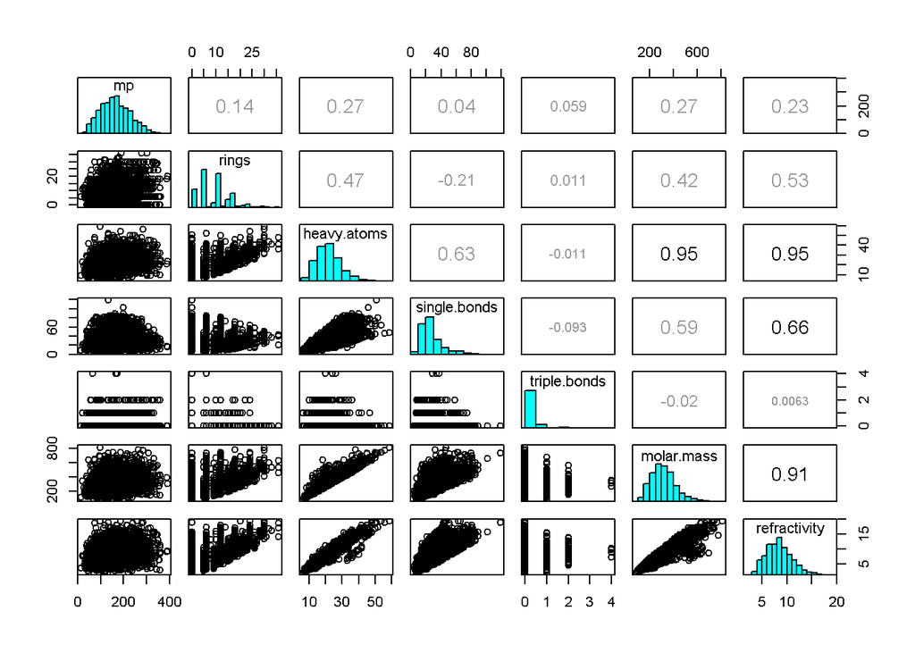

```r
numerics1 <-mp[,c(2:6,8:9)] #small first half
numerics2 <-mp[,c(11:18)] #second half
pairs(numerics1,upper.panel = panel.cor,diag.panel=panel.hist)
```

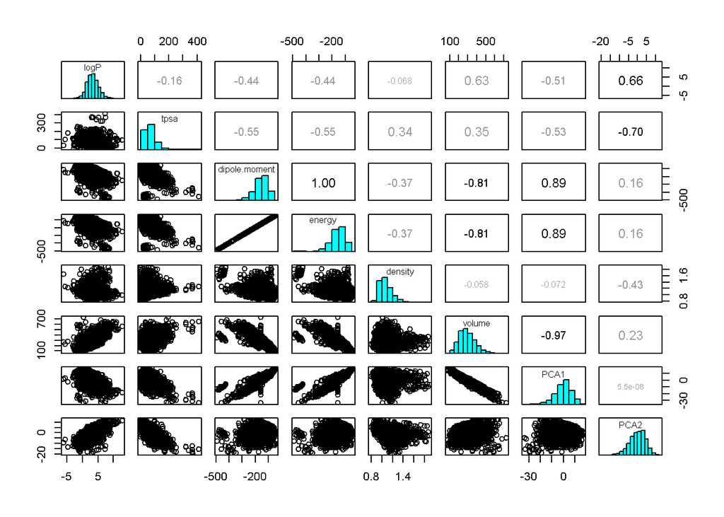

```r
pairs(numerics2,upper.panel = panel.cor,diag.panel=panel.hist)
```

### Linear regressions

Next I needed to do some linear regressions of the three 2D descriptors. I first did melting point and the dformal charge of the compound and found that the charge has a negative corelation with the melting point.

```r
mpxcharge <- lm(mp$mp~mp$formal.charge) #comparing melting point and formal charge
mpxcharge
```

```
##
## Call:
## lm(formula = mp$mp ~ mp$formal.charge)
##
## Coefficients:
##      (Intercept)  mp$formal.charge
##           165.57            -22.46
```

```r
summary(mpxcharge)
```

```
##
## Call:
## lm(formula = mp$mp ~ mp$formal.charge)
##
## Residuals:
##      Min       1Q   Median       3Q      Max
## -151.567  -47.567   -3.567   43.933  226.933
##
## Coefficients:
##                  Estimate Std. Error t value Pr(>|t|)
## (Intercept)      165.5672     0.9602 172.430  < 2e-16 ***
## mp$formal.charge -22.4622     4.5180  -4.972 6.89e-07 ***
## ---
## Signif. codes:  0 '***' 0.001 '**' 0.01 '*' 0.05 '.' 0.1 ' ' 1
##
## Residual standard error: 63.94 on 4448 degrees of freedom
## Multiple R-squared:  0.005526,   Adjusted R-squared:  0.005303
## F-statistic: 24.72 on 1 and 4448 DF,  p-value: 6.885e-07
```

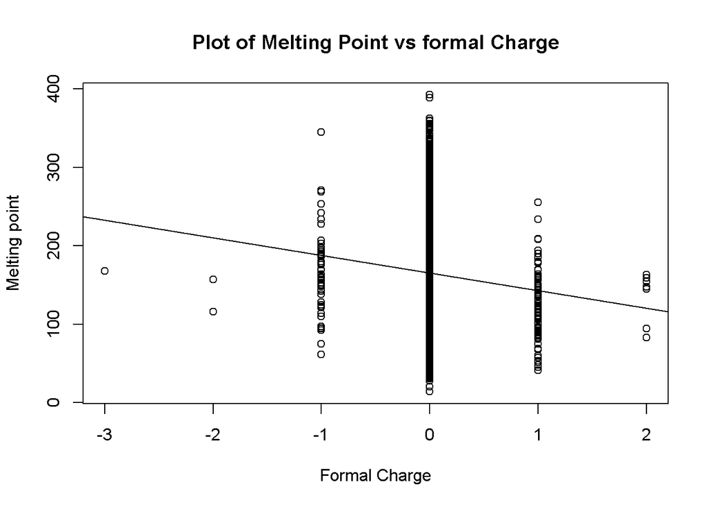

```r
plot(mp$mp~mp$formal.charge, main = "Plot of Melting Point vs formal Charge",        #doing an actual plot
     xlab = "Formal Charge", ylab = "Melting point")
abline(mpxcharge)
```

```r
mpxcharge$coefficients
```

```
##      (Intercept) mp$formal.charge
##        165.56722        -22.46217
```

```r
mpxchargefit <- mpxcharge$fitted.values #Just to take a look
#melting point has a negative correlation with formal charge
```

Next I did melting pont and volume and found there to be a positive correlation.

```r
#Doing mp and  volume
mpxvol <- lm(mp$mp~mp$volume) #comparing melting point and formal charge
mpxvol
```

```
##
## Call:
## lm(formula = mp$mp ~ mp$volume)
##
## Coefficients:
## (Intercept)    mp$volume
##    122.9602       0.1437
```

```r
summary(mpxvol)
```

```
##
## Call:
## lm(formula = mp$mp ~ mp$volume)
##
## Residuals:
##      Min       1Q   Median       3Q      Max
## -143.177  -47.840   -5.304   42.298  225.089
##
## Coefficients:
##              Estimate Std. Error t value Pr(>|t|)
## (Intercept) 122.96017    3.18370   38.62   <2e-16 ***
## mp$volume     0.14375    0.01033   13.92   <2e-16 ***
## ---
## Signif. codes:  0 '***' 0.001 '**' 0.01 '*' 0.05 '.' 0.1 ' ' 1
##
## Residual standard error: 62.77 on 4448 degrees of freedom
## Multiple R-squared:  0.04173,    Adjusted R-squared:  0.04151
## F-statistic: 193.7 on 1 and 4448 DF,  p-value: < 2.2e-16
```

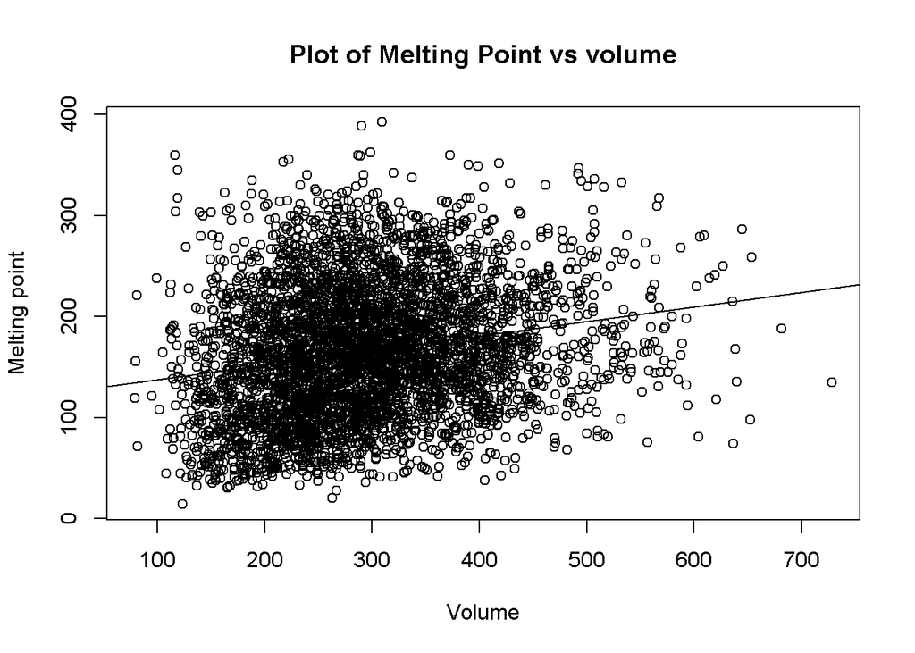

```r
plot(mp$mp~mp$volume, main = "Plot of Melting Point vs volume",        #doing an actual plot
     xlab = "Volume", ylab = "Melting point")
abline(mpxvol)
```

```r
mpxvol$coefficients
```

```
## (Intercept)   mp$volume
## 122.9601674   0.1437456
```

```r
mpxvolfit <- mpxvol$fitted.values
#There is a positive correlation between melting point and volume
```

And finally I did refractivity and melting point and found, again, a positive correlation.

```r
#Now doing refracvtivity and melting point
mpxref <- lm(mp$mp~mp$refractivity) #comparing melting point and formal charge
mpxref
```

```
##
## Call:
## lm(formula = mp$mp ~ mp$refractivity)
##
## Coefficients:
##     (Intercept)  mp$refractivity
##         117.474            5.616
```

```r
summary(mpxref)
```

```
##
## Call:
## lm(formula = mp$mp ~ mp$refractivity)
##
## Residuals:
##      Min       1Q   Median       3Q      Max
## -148.530  -47.402   -5.525   41.857  225.477
##
## Coefficients:
##                 Estimate Std. Error t value Pr(>|t|)
## (Intercept)     117.4745     3.1181   37.67   <2e-16 ***
## mp$refractivity   5.6159     0.3494   16.07   <2e-16 ***
## ---
## Signif. codes:  0 '***' 0.001 '**' 0.01 '*' 0.05 '.' 0.1 ' ' 1
##
## Residual standard error: 62.34 on 4448 degrees of freedom
## Multiple R-squared:  0.05489,    Adjusted R-squared:  0.05468
## F-statistic: 258.4 on 1 and 4448 DF,  p-value: < 2.2e-16
```

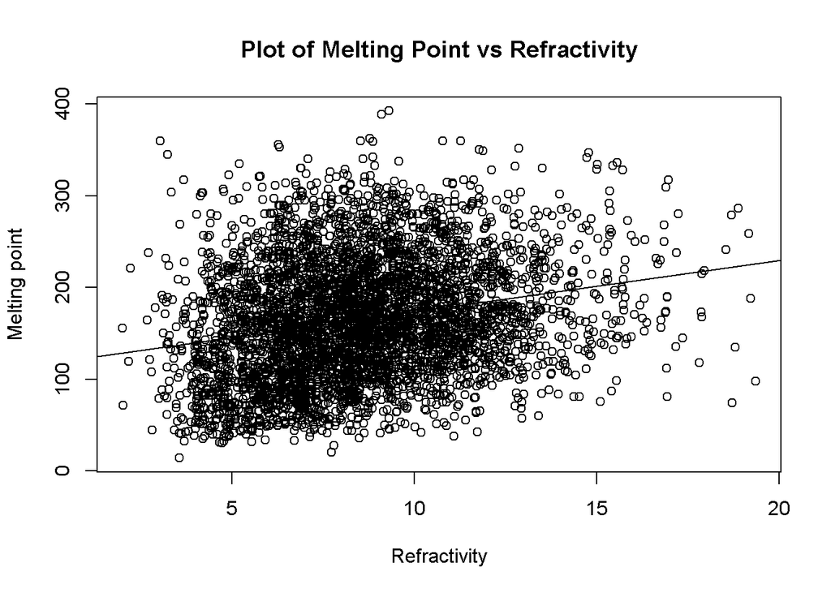

```r
plot(mp$mp~mp$refractivity, main = "Plot of Melting Point vs Refractivity",        #doing an actual plot
     xlab = "Refractivity", ylab = "Melting point")
abline(mpxref)
```

```r
mpxref$coefficients
```

```
##     (Intercept) mp$refractivity
##      117.474495        5.615857
```

```r
mpxreffit <- mpxref$fitted.values
#There is a positive corelation between refractivity and melting point
```